# MY TPPR

## Importation de Base_partie 2

pour effectuer n’importe quelle opération sur la base il est nécéssaire de l’importée.

```r
projetN<- read_excel("Base_Partie 2.xlsx",
                    range=NULL,
                    col_names = TRUE,
                    col_types = NULL,
                    )
```

### 2.1 Nettoyage et gestion des données

Ici, nous effectuerons certaines tache sur les variables et manipulerons les données manquantes

#### 2.1.1 Renommons la variable “country_destination” en “destination” et définissons les valeurs négatives comme manquantes.

Pour éxécuter cette tache, nous fairerons usage de la fonction **rename** de **dplyr**.

```r
projetN<- projetN %>% dplyr::rename(destination= country_destination)
#filtrage de toutes les valeurs négatives du data frame projet et leur remplacement par les NA supprimant ainsi les valeurs négatives de la base.
projetN[projetN < 0] <- NA
```

#### 2.1.2 Créons une nouvelle variable contenant des tranches d’âge de 5 ans en utilisant la variable “age”.

la variriable age possédant des données abhérantes, nous allons d’abord chercher à éliminer l’effet de ces valeurs. pour cela, nous procéderons à une imputation par la médiane. Le choix de cette méthode se justifie par le faite que la médiane est moins sensible au valeurs abhérantes.

```r
# calcul du premier et du troisième quartille qui serviront à déterminer l'écart interquartile
q1 <- quantile(projetN$age, 0.25)
q3 <- quantile(projetN$age, 0.75)
#calcul de l'écart interquartile iqr.
iqr <- q3 - q1
# calcul des bornes inférieurs et supérieurs qui nous servirrons à détecter les  valeurs aberrante
min1 <- q1 - 1.5 * iqr
max1 <- q3 + 1.5 * iqr

#  créons une nouvelle colone val_aber pour stocker les valeurs aberrantes remplacées par la médiane
projetN$val_aber <- ifelse((projetN$age < min1) | (projetN$age > max1),
                                    median(projetN$age,na.rm =TRUE ),
                                    projetN$age)
#créons les bornes pour les tranches d'age
bornes<-seq( min(projetN$val_aber),max(projetN$val_aber),by=5)
# création de la variable "tranche_age" contenant les tranches d'age
projetN <- within(projetN, tranche_age <- cut(val_aber, breaks = bornes))
#afficher la table des tranches d'ages
table(projetN$tranche_age)
```

```
##
## (15,20] (20,25] (25,30] (30,35] (35,40]
##      20      37      22      10       7
```

#### 2.1.3 Créer une nouvelle variable contenant le nombre d’entretiens réalisés par chaque agent recenseur.

Pour cela, nous créerons la table nbre_entre_ag contiendra le nombre d’occurrences de chaque valeur unique dans la colonne enumerator.la fonction match ici, recherche les positions des valeurs de projetN$enumerator dans names(nbre_entre_ag) (les noms des valeurs uniques dans la table nbre_entre_ag). Elle retourne un vecteur avec les positions correspondantes. pour chaque valeur de enuméretor,nbre_entre_ag[match(…)] renvoie le nombre d’entretients correspondant à cette valeur.

```r
nbre_entre_ag <- table(projetN$enumerator)
#création d'une nouvelle colone dans le projetN.
projetN$nbre_entretien<-nbre_entre_ag[match(projetN$enumerator,                                               names(nbre_entre_ag))]
```

#### 2.1.4 Créer une nouvelle variable qui affecte aléatoirement chaque répondant à un groupe de traitement (1) ou de controle (0).

Pour cela nous allons d’abord déterminer le nombre de ligne de projetN avec la fonction **nrow**. ensuite, nous ferons usage de la fonction sample qui génèrera aléatoirement soit 0, soit 1 à chaque différentes ligne.

```r
#Détermination du nombre de ligne du data frame projetN
nombre_total_respondants <- nrow(projetN)
#Génèration aléatoire des valeur 0 et 1 aux différentes lignes.
projetN$alea_affect <- sample(c(1, 0), size = nombre_total_respondants, replace = TRUE,prob=NULL)
```

#### 2.1.5 Fusionner la taille de la population de chaque district (feuille 2) avec l’ensemble de données (feuille 1) afin que toutes les personnes interrogées aient une valeur correspondante représentant la taille de la population du district dans lequel elles vivent.

La feuille une de Base_partie 2 étant déja importée, nous importerons maintenant uniquement la feuille deux de ce fichier.Puis à l’aide de la fonction merge nous aurons le résultat souhaiter.

```r
#importation de la feuille 2 de Base_partie 2
projetN2<- read_excel("Base_Partie 2.xlsx",sheet="district")
#Création du data frame fusion qui contient la fusion des deux feuilles.
fusion <- merge(projetN, projetN2, by = "district", all.x = TRUE)
```

#### 2.1.6 Calculer la durée de l’entretien et indiquer la durée moyenne de l’entretien par enquêteur.

Pour cela nous créerons d’abord une varible qui contient la durée de chaque entretient.Ensuite à l’aide ces durées, nous déterminerons la durée moyenne par enqueteur.

```r
projetN$starttime <- as.POSIXct(projetN$starttime , format = "%Y-%m-%d %H:%M")
projetN$endtime <- as.POSIXct(projetN$endtime, format = "%Y-%m-%d %H:%M")

# Calculer la durée de l'entretien (en minutes)
projetN$duree_entretien <- difftime(projetN$endtime, projetN$starttime, units = "mins")

# Calculer la durée moyenne de l'entretien par enquêteur
dur_moy_enq <- aggregate(projetN$duree_entretien,
                                         by = list(enqueteur = projetN$enumerator),
                                         FUN = mean)

# Renommer les colonnes du résultat
colnames(dur_moy_enq) <- c("enqueteur", "duree_moyenne_entretien")

# Afficher le résultat
print(dur_moy_enq)
```

```
##    enqueteur duree_moyenne_entretien
## 1          1           68.14667 mins
## 2          4           36.48333 mins
## 3          5           33.55833 mins
## 4          6           25.84667 mins
## 5          7           37.16429 mins
## 6          8           40.13056 mins
## 7          9          114.76667 mins
## 8         10           55.27667 mins
## 9         11           33.48333 mins
## 10        12           48.16667 mins
## 11        13           31.59583 mins
## 12        14           25.56111 mins
## 13        15           28.65000 mins
## 14        17           29.28611 mins
## 15        18           36.85833 mins
## 16        20           28.76852 mins
```

#### 2.1.7 Renommez toutes les variables de l’ensemble de données en ajoutant le préfixe “endline_”

Ici, nous ferons usage de la fonction paste() qui est utilisée pour créer un nouveau vecteur de noms de colonnes en ajoutant le préfixe “endline_” à chaque nom de colonne existant. Le paramètre sep = “” spécifie que les éléments sont concaténés sans espace entre le préfixe et les noms de colonnes existants.

```r
# Renommer les variables en ajoutant le préfixe "endline_"
new_names <- paste("endline_", names(projetN), sep = "")
#attribution au nouvel objet de noms de colonnes, new_names, à l'objet de données projetN.
names(projetN) <- new_names
```

### 2.2 ANALYSE ET VISUALISATION DES DONNEES

Dans cette section nous ferons ressortir quelques tableaux,et nous éffectuerons également quelques tests.

#### 2.2.1 Créez un tableau récapitulatif contenant l’âge moyen et le nombre moyen d’enfants par district.

```r
projetN %>%
  #création du tableau à l'aide de la fonction tbl_summary de gtsummary
  gtsummary::tbl_summary(
    include = c(endline_val_aber,endline_children_num ),
    by =endline_district,
    statistic = all_continuous() ~ " {mean} "
  )%>%
  modify_header(label ~ "**Variables**") %>%
  modify_spanning_header(c("stat_1", "stat_2") ~ "**district**") %>%
  #afficher le titre du tableau
  modify_caption("**Tableau recap age et nombre moyen d''enfant par discrit**") %>%
  # Mettre les variables en gras
  bold_labels()
```

**Tableau recap age et nombre moyen d’’enfant par discrit**

[output not shown]

<sup>1</sup> Mean ; n (%)

#### 2.2.2 Testons si la différence d’âge entre les sexes est statistiquement significative au niveau de 5 %.

D’après le test, on obtient une pie-value de **0.061** qui est supérieur à 5% donc la différence d’age entre les sexes n’est pas statistiquement significatif.

```r
projetN %>%
  gtsummary::tbl_summary(
    include = endline_val_aber,
    by = endline_sex
  ) %>%
  #idiquons la différence entre les différentes catégories à l'aide de la fonction add_difference()
  add_difference()
```

| **Characteristic** | **0**, N = 86<sup>1</sup> | **1**, N = 11<sup>1</sup> | **Difference**<sup>2</sup> | **95% CI**<sup>2,3</sup> | **p-value**<sup>2</sup> |
| --- | --- | --- | --- | --- | --- |
| endline_val_aber | 24.0 (21.0, 29.0) | 21.0 (18.0, 23.0) | 3.4 | -0.17, 6.9 | 0.061 |

<sup>1</sup> Median (IQR)  
<sup>2</sup> Welch Two Sample t-test  
<sup>3</sup> CI = Confidence Interval

#### 2.2.3 Créer un nuage de points de l’âge en fonction du nombre d’enfants

Pour cette question nous ferrons usage de ggplot pour avoir un nuage de point un peu jolie.

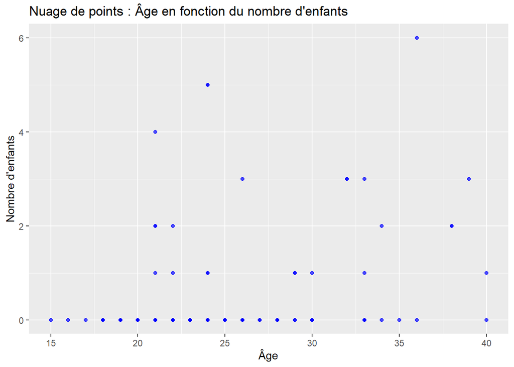

```r
ggplot(projetN) +
  aes(x = endline_val_aber, y =endline_children_num ) +
  geom_point(color = "blue", alpha = 0.7) +
  labs(x = "Âge", y = "Nombre d'enfants", title = "Nuage de points : Âge en fonction du nombre d'enfants")# Donne l'institulé des différents axes ainsi que le titre du graphique.
```

#### 2.2.4 La variable “intention” indiquons si les migrants potentiels ont l’intention de migrer sur une échelle de 1 à 7. Estimons l’effet de l’appartenance au groupe de traitement sur l’intention de migrer.

Pour l’estimation, nous allons effectuer un test à l’aide d’un model de regression linéaire simple.

```r
#lm nécessaire pour éffectuer de la regression
model <- lm(endline_intention ~endline_alea_affect , data = projetN)
tbl_regression(model) #permet d'afficher le tableaude regression
```

| **Characteristic** | **Beta** | **95% CI**<sup>1</sup> | **p-value** |
| --- | --- | --- | --- |
| endline_alea_affect | 0.36 | -0.33, 1.1 | 0.3 |

<sup>1</sup> CI = Confidence Interval

#### 2.2.5 Créez un tableau de régression avec 3 modèles. Les résultats des trois modèles doivent être affichés dans un seul tableau.

Etant donné que nous n’avons pas encore les baggages nécessaires pour les interprétations des modéles, dans cette partie nous nous limiterrons à la présentation du resultat demandé.

```r
#MODEL A:Modèle vide - Effet du traitement sur les intentions
modele_A<-lm(endline_intention ~endline_alea_affect , data = projetN)
mod1<-tbl_regression(modele_A)

#Model B: Effet du traitement sur les intentions en tenant compte de l’âge et du sexe
modele_B<-lm(endline_intention ~endline_alea_affect+endline_val_aber+endline_sex , data = projetN)
mod2<-tbl_regression(modele_B)

#Model C: Identique au modèle B mais en contrôlant le district.
modele_C<-lm(endline_intention ~endline_alea_affect+endline_val_aber+endline_sex+endline_district , data = projetN)
mod3<-tbl_regression(modele_C)

#combinaison des modèles dans un seul tableau
tbl_merge(list(mod1, mod2, mod3))%>% modify_caption("**Tableau de regression final**",text_interpret = c("md","html"))
```

**Tableau de regression final**

| **Characteristic** | **Table 1** **Beta** | **Table 1** **95% CI**<sup>1</sup> | **Table 1** **p-value** | **Table 2** **Beta** | **Table 2** **95% CI**<sup>1</sup> | **Table 2** **p-value** | **Table 3** **Beta** | **Table 3** **95% CI**<sup>1</sup> | **Table 3** **p-value** |
| --- | --- | --- | --- | --- | --- | --- | --- | --- | --- |
| endline_alea_affect | 0.36 | -0.33, 1.1 | 0.3 | 0.29 | -0.41, 0.99 | 0.4 | 0.27 | -0.43, 0.97 | 0.4 |
| endline_val_aber |  |  |  | 0.02 | -0.04, 0.08 | 0.6 | 0.02 | -0.04, 0.09 | 0.4 |
| endline_sex |  |  |  | -0.80 | -1.9, 0.32 | 0.2 | -0.70 | -1.8, 0.43 | 0.2 |
| endline_district |  |  |  |  |  |  | 0.10 | -0.06, 0.25 | 0.2 |

<sup>1</sup> CI = Confidence Interval